# DMBT1 Mice Microbiome Study – Stable Taxa Identification

Simon Fontaine

22/04/2023

# Data description

## Study design

The goal of the study is to understand the interaction between

- The DBMT1 gene
- The oral microbiome
- Oral Squamous Cell Carcinoma (OSCC) progression

Sixty-five (65) mice were bred into two groups: wild-type (WT) and DMBT1 knock-out (KO). At some pre-specified time (labeled week 0 here after), a carcinogen was introduce to induce OSCC. Saliva sample were collected over time for each mouse and 16S sequencing was performed.

Cancer progression was measured at the end of the study (22 weeks) and classified into three categories: hyperplasia, carcinoma in situ (CIS) and squamous cell carcinoma (SCC). The researcher also suspect that sex may play a role, so sex was also recorded.

## Available data

For each mouse:

- Sex (M/F)
- Cancer progression at week 22 (hyperplasia, CIS, SCC)
- Genotype (WT/KO)
- Longitudinal microbial composition (1726 OTUs with taxonomy)
  - Measured at weeks 0, 4, 8, 12, 16 and 22
  - Not all time points are available: we only have 294 samples (4.5 samples/mouse)
  - I only have taxonomy up to Genus level

## Summaries

# OTU-level analysis (presence/absence)

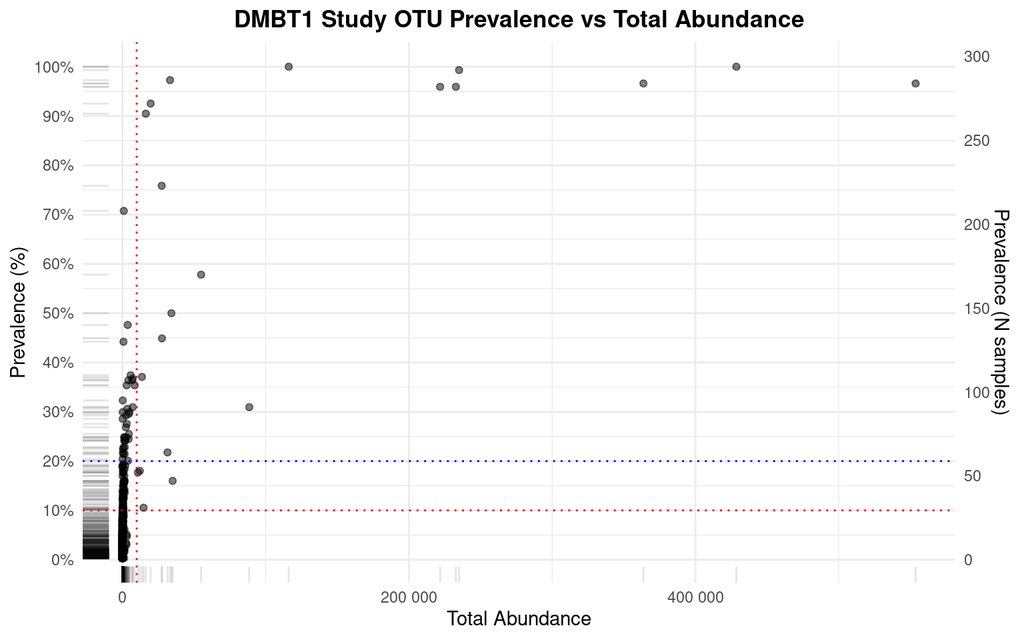

```r
dat = pseq

lubomTaxaStats = tibble(taxon = taxa_names(dat),
                        prevalence = prevalence(dat),
                        total_abundance = taxa_sums(dat),
                        nSamples = nsamples(dat)*prevalence(dat))

lubomTaxaStats %>%
  ggplot() +
  aes(x = total_abundance, y = prevalence) +
  geom_point(alpha = 0.5) +
  geom_rug(alpha = 0.1) +
  labs(title = "DMBT1 Study OTU Prevalence vs Total Abundance") +
  scale_x_continuous(labels = scales::label_number(), name = "Total Abundance") +
  scale_y_continuous(labels = scales::label_percent(),
                     breaks = scales::breaks_pretty(n = 11),
                     name = "Prevalence (%)",
                     sec.axis = sec_axis(trans = ~ . * nsamples(dat),
                                         breaks = scales::breaks_pretty(n = 11),
                                         name = "Prevalence (N samples)")) +
  geom_vline(xintercept = 10000, color = "red", linetype = "dotted") +
  geom_hline(yintercept = 0.1, color = "red", linetype = "dotted") +
  geom_hline(yintercept = 0.2, color = "blue", linetype = "dotted") +
  theme(plot.title = element_text(hjust = 0.5, face = "bold"))
```

```r
# prevalent taxa (prevalence > 0.1)
prev_tax = lubomTaxaStats %>%
  filter(prevalence > 0.1) %>%
  dplyr::select(taxon) %>%
  pull()

# rare taxa (prevalence <= 0.1)
rare_tax = lubomTaxaStats %>%
  filter(prevalence <= 0.1 & nSamples == 1) %>%
  dplyr::select(taxon) %>%
  pull()
```

```r
# make the raw data compositional
dat_rel = dat %>%
  tax_transform("compositional")

# get an OTU table for prevalent taxa
otu_prev_tax = otu_table(dat_rel)[, prev_tax] %>%
  as.data.frame() %>%
  rownames_to_column(".sample_name")

# get an OTU table for rare taxa
otu_rare_tax = otu_table(dat_rel)[, rare_tax] %>%
  as.data.frame() %>%
  rownames_to_column(".sample_name")

sample_df = dat_rel %>% samdat_tbl()
```

```r
dat_tax = prev_tax

# # merge relative abundance data and sample data (clinical data)
# sample_df = merge(sample_df, otu_prev_tax, by = ".sample_name") %>%
#   group_by(sampleName) %>%
#   filter(all(c("0", "6", "12") %in% t)) %>%
#   filter(t %in% c("0", "6", "12")) %>%
#   ungroup() %>%
#   mutate(t = as.numeric(t),
#          PD = as.factor(PD))

sample_df = merge(sample_df, otu_prev_tax, by = ".sample_name") %>%
  mutate(
    t = visit_id,
    subject_id = as.factor(subject_id)
  )
```

```r
glmer_icc_calc = function(df, spec, pres_thre) {
data = df %>%
    mutate(across(all_of(spec), function(x) ifelse(x > pres_thre, 1, 0))) %>%
    mutate(across(all_of(spec), as.factor)) %>%
    data.table::setnames(spec, paste("OTU_", rep(1:length(spec)), sep = "")) # change the long taxa names before fitting GLMMs

  resp = data %>%
    dplyr::select(contains("OTU")) %>%
    colnames()

  models = list()
  icc = c()
  reVar = c()

  for (i in resp) {
    resp_var = data %>% select(i) %>% var()

    # if the response variable has 0 variance for a certain taxon (i.e., it's either all present/absent across all samples), set ICC and random effects variance to 0 - we're not interested in those taxa
    if (resp_var == 0) {
      icc = append(icc, 0)
      reVar = append(reVar, 0)
    }

    else{
      f = formula(paste(i, " ~ t + Type + (1|subject_id)")) # treat time points (t) and PD status (PD) as fixed effects, while treating sample IDs as a random effect
      models[[i]] = glmer(f, data, family = binomial,
                          control = glmerControl(optimizer = "bobyqa",
                                                 optCtrl = list(maxfun = 2e4)),
                          nAGQ = 10) # used nAGQ = 10 to reduce computational time but the higher, the greater accuracy in the evaluation of the log-likelihood it produces

      # if a model is singular, set ICC and random effects variance to 0
      if (isSingular(models[[i]]) == TRUE) {
        icc = append(icc, 0)
        reVar = append(reVar, 0)
      }
      else {
        icc = append(icc, performance::icc(models[[i]])$ICC_adjusted)
        reVar = append(reVar, as.data.frame(VarCorr(models[[i]]))$vcov[1])
      }
    }
  }
  return(list(models, icc, reVar))
}
```

```r
# test different threshold values for determining whether a taxon is present or not.
m0 = glmer_icc_calc(sample_df, dat_tax, 0)
m1 = glmer_icc_calc(sample_df, dat_tax, 0.001)
m2 = glmer_icc_calc(sample_df, dat_tax, 0.002)
m3 = glmer_icc_calc(sample_df, dat_tax, 0.003)
m4 = glmer_icc_calc(sample_df, dat_tax, 0.004)
m5 = glmer_icc_calc(sample_df, dat_tax, 0.005)
m6 = glmer_icc_calc(sample_df, dat_tax, 0.006)
m7 = glmer_icc_calc(sample_df, dat_tax, 0.007)
m8 = glmer_icc_calc(sample_df, dat_tax, 0.008)
m9 = glmer_icc_calc(sample_df, dat_tax, 0.009)
m10 = glmer_icc_calc(sample_df, dat_tax, 0.01)
```

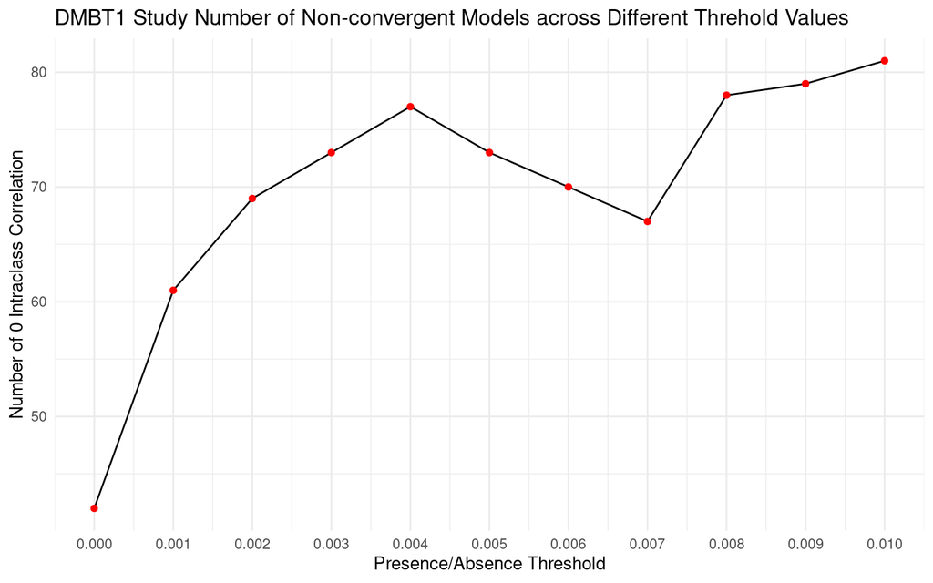

```r
non_conv = c(sum(m0[[2]] == 0),
             sum(m1[[2]] == 0),
             sum(m2[[2]] == 0),
             sum(m3[[2]] == 0),
             sum(m4[[2]] == 0),
             sum(m5[[2]] == 0),
             sum(m6[[2]] == 0),
             sum(m7[[2]] == 0),
             sum(m8[[2]] == 0),
             sum(m9[[2]] == 0),
             sum(m10[[2]] == 0))

thre_df = tibble(Threshold = c(0, seq(0.001, 0.01, by = 0.001)),
                       Non_Convergence = non_conv)

thre_df %>%
  ggplot() +
  aes(x = Threshold, y = Non_Convergence) +
  geom_line() +
  geom_point(color = "red") +
  labs(x = "Presence/Absence Threshold", y = "Number of 0 Intraclass Correlation",
       title = "DMBT1 Study Number of Non-convergent Models across Different Threhold Values") +
  scale_x_continuous(breaks = c(0, seq(0.001, 0.01, by = 0.001)))
```

```r
# given 0 threshold yields the smallest number of non-convergent models, use 0 to determine whether a taxon is present or absent
# relative abundance > 0 - present == 1, otherwise absent == 0
best_m = m0
```

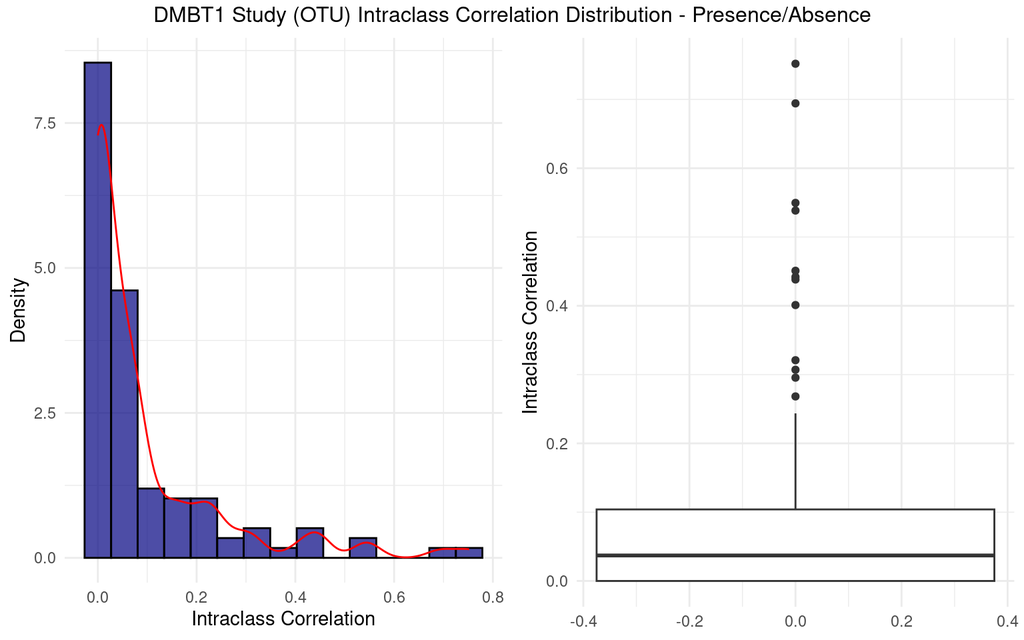

```r
icc_df = tibble(ASV = dat_tax,
                Kingdom = tax_table(dat_rel)[dat_tax, 1] %>% as.vector(),
                Phylum = tax_table(dat_rel)[dat_tax, 2] %>% as.vector(),
                Class = tax_table(dat_rel)[dat_tax, 3] %>% as.vector(),
                Order = tax_table(dat_rel)[dat_tax, 4] %>% as.vector(),
                Family = tax_table(dat_rel)[dat_tax, 5] %>% as.vector(),
                Genus = tax_table(dat_rel)[dat_tax, 6] %>% as.vector(),
                Prevalence = prevalence(dat %>% tax_filter(min_prevalence = 0.1)),
                ICC = best_m[[2]],
                REVar = best_m[[3]])

icc_hist = icc_df %>%
  ggplot() +
  aes(x = ICC, y = ..density..) +
  geom_histogram(bins = 15, fill = "navy", color = "black", alpha = 0.7) +
  geom_density(lwd = 0.5, linetype = 1, color = "red") +
  labs(x = "Intraclass Correlation", y = "Density")

icc_box = icc_df %>%
  ggplot() +
  aes(x = ICC) +
  geom_boxplot() +
  coord_flip() +
  labs(x = "Intraclass Correlation")

grid.arrange(icc_hist, icc_box, ncol = 2,
             top = grid::textGrob("DMBT1 Study (OTU) Intraclass Correlation Distribution - Presence/Absence"))
```

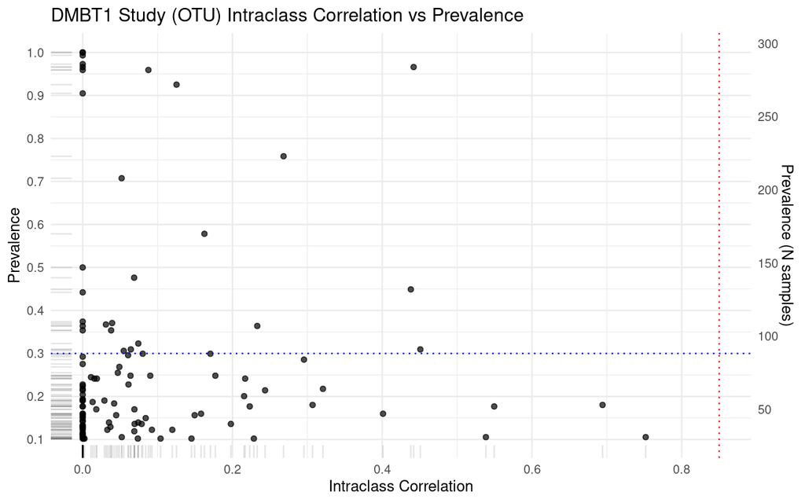

```r
icc_df %>%
  ggplot() +
  aes(x = ICC, y = Prevalence) +
  geom_point(alpha = 0.7) +
  geom_rug(alpha = 0.1) +
  labs(title = "DMBT1 Study (OTU) Intraclass Correlation vs Prevalence") +
  scale_x_continuous(labels = scales::label_number(), name = "Intraclass Correlation") +
  scale_y_continuous(labels = scales::label_number(),
                     breaks = scales::breaks_pretty(n = 10),
                     sec.axis = sec_axis(trans ~ . * nsamples(dat_rel),
                                         breaks = scales::breaks_pretty(n = 10),
                                         name = "Prevalence (N samples)")) +
  geom_vline(xintercept = 0.85, color = "red", linetype = "dotted") +
  geom_hline(yintercept = 0.3, color = "blue", linetype = "dotted")
```

```r
stab_thre = 0.85
prev_thre = 0.3
icc_df = icc_df %>%
  mutate(Stable = as.factor(case_when(ICC >= stab_thre ~ 1,
                                      TRUE ~ 0)),
         Prevalent = as.factor(case_when(Prevalence >= prev_thre ~ 1,
                                         TRUE ~ 0)),
         StabPrev = as.factor(case_when(Stable == "1" & Prevalent == "1" ~ 1,
                                        Stable == "1" & Prevalent == "0" ~ 2,
                                        Stable == "0" & Prevalent == "1" ~ 3,
                                        Stable == "0" & Prevalent == "0" ~ 4)))
icc_df
```

```
## # A tibble: 109 × 13
##    ASV    Kingdom Phylum Class Order Family Genus Prevalence    ICC REVar Stable
##    <chr>  <chr>   <chr>  <chr> <chr> <chr>  <chr>      <dbl>  <dbl> <dbl> <fct>
##  1 Otu00… d__Bac… p__Pr… c__G… o__P… f__Pa… <NA>       0.966 0.442  2.61  0
##  2 Otu00… d__Bac… p__Pr… c__G… o__P… f__Pa… <NA>       1     0      0     0
##  3 Otu00… d__Bac… p__Ac… c__A… o__A… f__Co… g__C…      0.966 0      0     0
##  4 Otu00… d__Bac… p__Fi… c__B… o__L… f__St… g__S…      0.993 0      0     0
##  5 Otu00… d__Bac… p__Fi… c__B… o__L… f__La… g__L…      0.959 0.0877 0.316 0
##  6 Otu00… d__Bac… p__Fi… c__B… o__L… f__St… g__S…      0.959 0      0     0
##  7 Otu00… d__Bac… p__Pr… c__B… o__B… f__Bu… g__C…      1     0      0     0
##  8 Otu00… d__Bac… p__Pr… c__B… o__N… f__Ne… g__N…      0.310 0.451  2.70  0
##  9 Otu00… d__Bac… p__Fi… c__B… o__B… f__St… g__S…      0.578 0.163  0.639 0
## 10 Otu00… d__Bac… p__Fu… c__F… o__F… f__Le… <NA>       0.160 0.401  2.20  0
## # ℹ 99 more rows
## # ℹ 2 more variables: Prevalent <fct>, StabPrev <fct>
```

# Genus-level analysis (numerical)

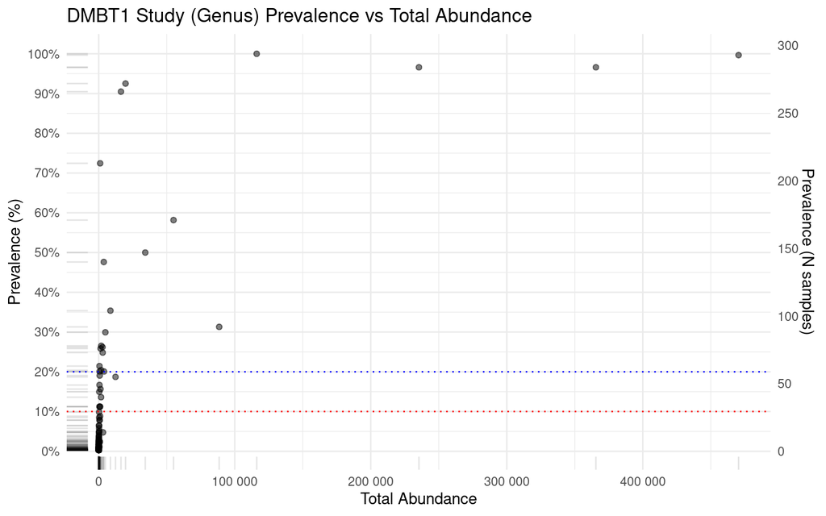

```r
dat_gen = pseq %>% tax_glom("Genus")

dat_genTaxaStats = tibble(taxon = taxa_names(dat_gen),
                          prevalence = prevalence(dat_gen),
                          total_abundance = taxa_sums(dat_gen),
                          species = tax_table(dat_gen)[, 6] %>% as.vector())

dat_genTaxaStats %>%
  ggplot() +
  aes(x = total_abundance, y = prevalence) +
  geom_point(alpha = 0.5) +
  geom_rug(alpha = 0.1) +
  labs(title = "DMBT1 Study (Genus) Prevalence vs Total Abundance") +
  scale_x_continuous(labels = scales::label_number(), name = "Total Abundance") +
  scale_y_continuous(labels = scales::label_percent(),
                     breaks = scales::breaks_pretty(n = 10),
                     name = "Prevalence (%)",
                     sec.axis = sec_axis(trans ~ . * nsamples(dat_gen),
                                         breaks = scales::breaks_pretty(n = 10),
                                         name = "Prevalence (N samples)")) +
  geom_hline(yintercept = 0.1, color = "red", linetype = "dotted") +
  geom_hline(yintercept = 0.2, color = "blue", linetype = "dotted")
```

```r
dat_gen_rel = dat_gen %>%
  tax_filter(min_prevalence = 0.05) %>%
  tax_transform("compositional")

spec_gen = tax_table(dat_gen_rel)[, 6] %>% as.vector()

gen_sample_df = dat_gen_rel %>%
  samdat_tbl()

gen_sample_df[, spec_gen] = NA

for (i in 1:length(spec_gen)) {
  j = which.max(spec_gen[i] == colnames(gen_sample_df))
  gen_sample_df[, j] = otu_table(dat_gen_rel)[, i] %>% as.vector()
}

# I think this was specific to your data?
# gen_sample_df = gen_sample_df %>%
#   group_by(subject_id) %>%
#   filter(all(c("0", "6", "12") %in% t)) %>%
#   filter(t %in% c("0", "6", "12")) %>%
#   ungroup() %>%
#   mutate(t = as.numeric(t),
#          PD = as.factor(PD))
gen_sample_df = gen_sample_df %>%
  mutate(
    t = visit_id,
    subject_id = as.factor(subject_id)
  )
```

```r
resp = gen_sample_df %>%
  dplyr::select(spec_gen) %>%
  clean_names() %>%
  colnames()

models = list()
icc = c()
reVar = c()

for (i in resp) {
  f = formula(paste(i, " ~ t + type + (1|subject_id)"))
  models[[i]] = lmer(f, gen_sample_df %>% clean_names(), REML = TRUE)
    if (isSingular(models[[i]]) == TRUE) {
    icc = append(icc, 0)
    reVar = append(reVar, 0)
  }

  else {
  icc = append(icc, performance::icc(models[[i]])$ICC_adjusted)
  reVar = append(reVar, as.data.frame(VarCorr(models[[i]]))$vcov[1])
  }
}
```

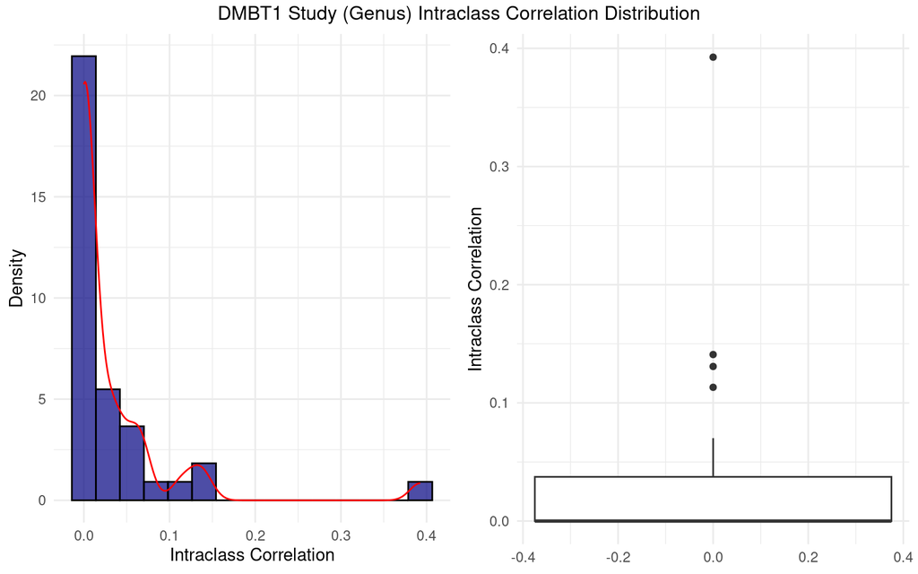

```r
data_gen = dat_gen %>%
  tax_filter(min_prevalence = 0.05)

icc_df = tibble(Species = spec_gen,
                Prevalence = prevalence(data_gen),
                ICC = icc,
                REVar = reVar)

icc_hist = icc_df %>%
  ggplot() +
  aes(x = ICC, y = ..density..) +
  geom_histogram(bins = 15, fill = "navy", color = "black", alpha = 0.7) +
  geom_density(lwd = 0.5, linetype = 1, color = "red") +
  labs(x = "Intraclass Correlation", y = "Density")

icc_box = icc_df %>%
  ggplot() +
  aes(x = ICC) +
  geom_boxplot() +
  coord_flip() +
  labs(x = "Intraclass Correlation")

grid.arrange(icc_hist, icc_box, ncol = 2,
             top = grid::textGrob("DMBT1 Study (Genus) Intraclass Correlation Distribution"))
```

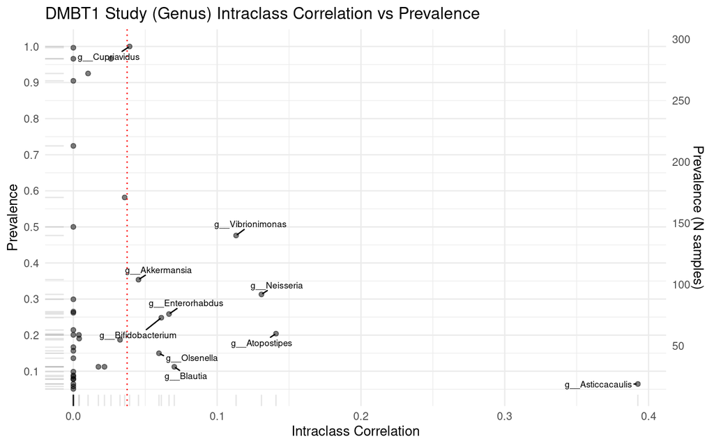

```r
icc_thre = quantile(icc_df$ICC, probs = 0.75)

icc_df %>%
  ggplot() +
  aes(x = ICC, y = Prevalence) +
  geom_point(alpha = 0.5) +
  geom_rug(alpha = 0.1) +
  labs(title = "DMBT1 Study (Genus) Intraclass Correlation vs Prevalence") +
  scale_x_continuous(labels = scales::label_number(), name = "Intraclass Correlation") +
  scale_y_continuous(labels = scales::label_number(),
                     breaks = scales::breaks_pretty(n = 10),
                     sec.axis = sec_axis(trans ~ . * nsamples(data_gen),
                                         breaks = scales::breaks_pretty(n = 10),
                                         name = "Prevalence (N samples)")) +
  geom_vline(xintercept = icc_thre, color = "red", linetype = "dotted") +
  ggrepel::geom_text_repel(data = function(df) filter(df, ICC > icc_thre),
                           mapping = aes(label = Species), size = 2.5, min.segment.length = 0, force = 15)
```

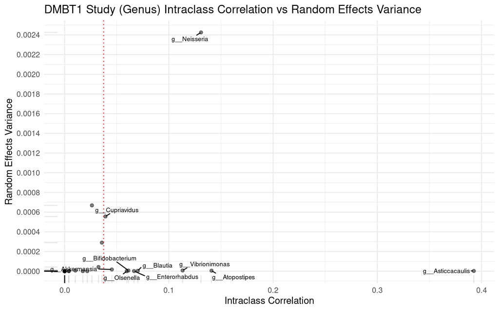

```r
icc_df %>%
  ggplot() +
  aes(x = ICC, y = REVar) +
  geom_point(alpha = 0.5) +
  geom_rug(alpha = 0.1) +
  labs(title = "DMBT1 Study (Genus) Intraclass Correlation vs Random Effects Variance") +
  scale_x_continuous(labels = scales::label_number(), name = "Intraclass Correlation") +
  scale_y_continuous(labels = scales::label_number(),
                     breaks = scales::breaks_pretty(n = 10),
                     name = "Random Effects Variance") +
  geom_vline(xintercept = icc_thre, color = "red", linetype = "dotted") +
  ggrepel::geom_text_repel(data = function(df) filter(df, ICC > icc_thre),
                           mapping = aes(label = Species), size = 2.5, min.segment.length = 0, force = 15)
```